# Lesson 3

### What to Do First?

Notes:

### Pseudo-Facebook User Data

Notes:

### Histogram of Users’ Birthdays

Notes:

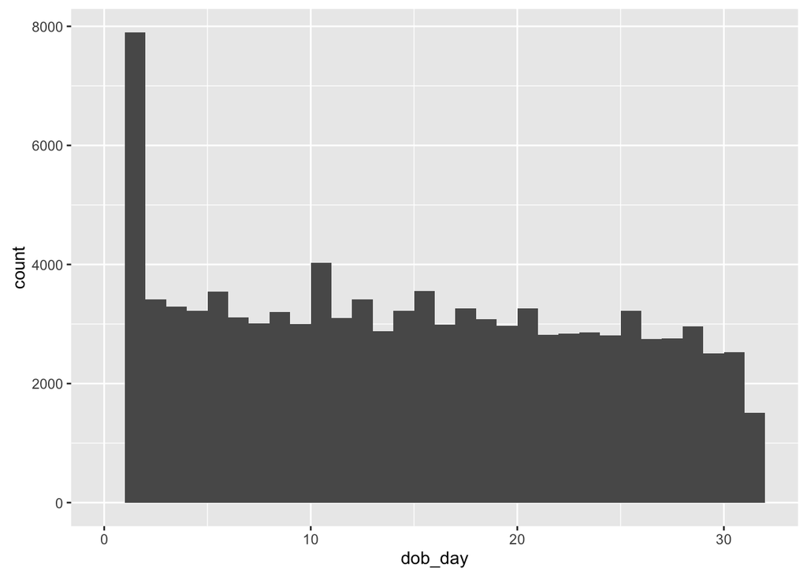

```r
#install.packages('ggplot2')
library(ggplot2)

#install.packages("gridExtra")
library(gridExtra)

qplot(x = dob_day, data = pf)
```

```r
# scale_x_continuous(breaks = 1:31)
```

#### What are some things that you notice about this histogram?

Response:

The scale_x_discrete() function throws an error in my console. The histogram is very skewed toward the first day of the month. ***

### Moira’s Investigation

Notes:

### Estimating Your Audience Size

Notes:

#### Think about a time when you posted a specific message or shared a photo on Facebook. What was it?

Response:

#### How many of your friends do you think saw that post?

Response:

#### Think about what percent of your friends on Facebook see any posts or comments that you make in a month. What percent do you think that is?

Response:

### Perceived Audience Size

Notes:

### Faceting

Notes:

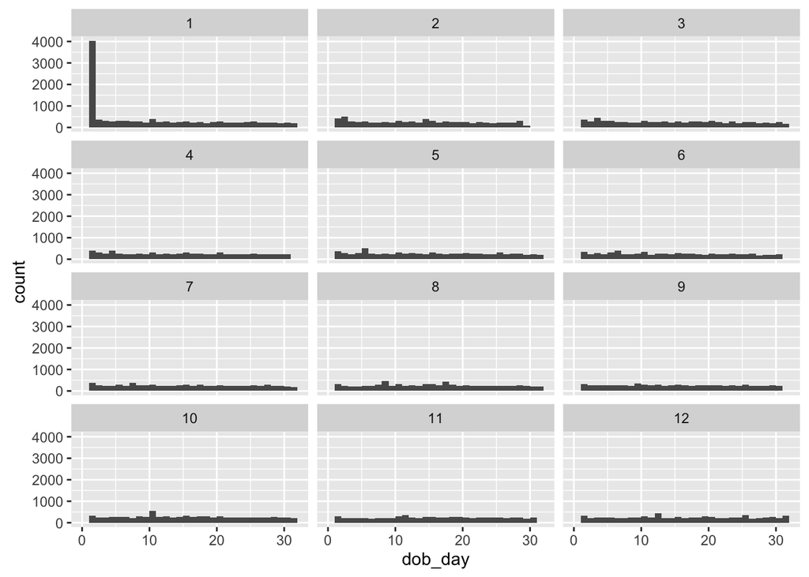

```r
qplot(x = dob_day, data = pf) +
    facet_wrap(~dob_month, ncol = 3)
```

#### Let’s take another look at our plot. What stands out to you here?

Response:

There is a disproportionate number of people born on January 1st. ***

### Be Skeptical - Outliers and Anomalies

Notes:

### Friend Count

Notes:

#### What code would you enter to create a histogram of friend counts?

#### How is this plot similar to Moira’s first plot?

Response:

### Limiting the Axes

Notes: The xlim parameter will truncate everything larger than the upper bound.

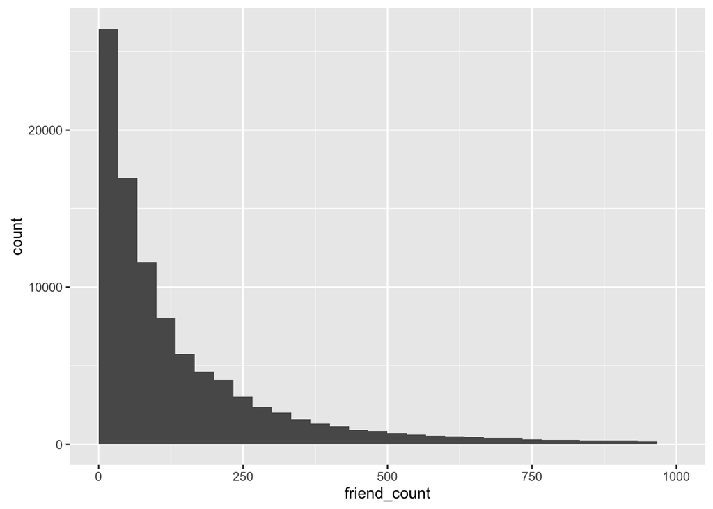

```r
qplot(x = friend_count, data = pf, xlim = c(0, 1000))
```

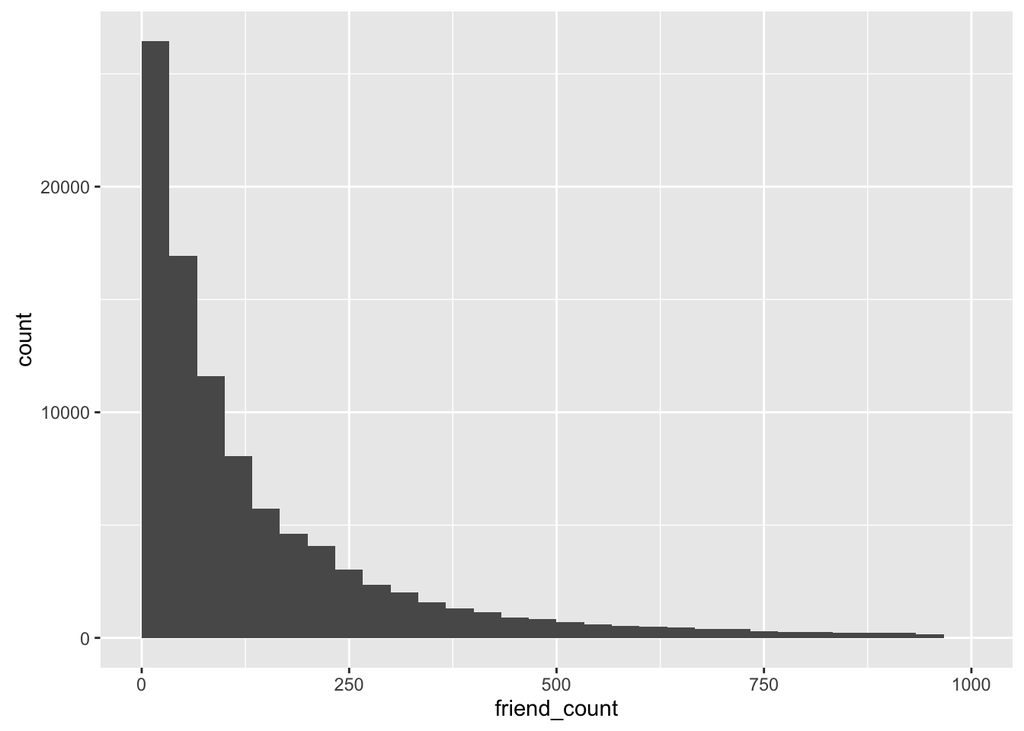

```r
qplot(x = friend_count, data = pf, xlim = c(0, 1000)) +
    scale_x_continuous(limits = c(0, 1000))
```

### Exploring with Bin Width

Notes: Bin width governs the width of the bars in a histogram. ***

### Adjusting the Bin Width

Notes:

### Faceting Friend Count

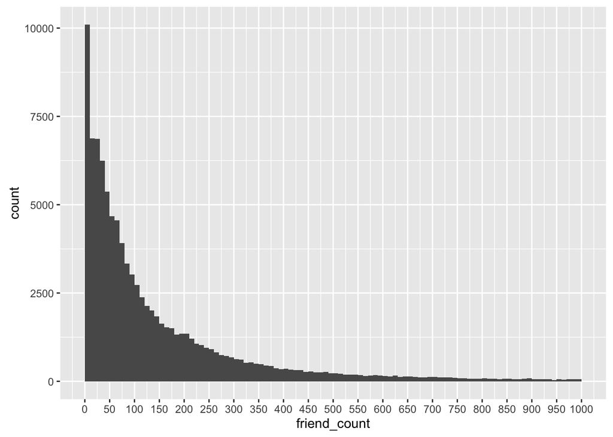

```r
# What code would you add to create a facet the histogram by gender?
# Add it to the code below.
qplot(x = friend_count, data = pf, binwidth = 10) +
  scale_x_continuous(limits = c(0, 1000),
                     breaks = seq(0, 1000, 50))
```

### Omitting NA Values

Notes: You can use na.omit() to omit all rows with NA values in a column

### Statistics ‘by’ Gender

Notes:

```r
by(pf$friend_count, pf$gender, summary)
```

```
## pf$gender: female
##    Min. 1st Qu.  Median    Mean 3rd Qu.    Max.
##       0      37      96     242     244    4923
## --------------------------------------------------------
## pf$gender: male
##    Min. 1st Qu.  Median    Mean 3rd Qu.    Max.
##       0      27      74     165     182    4917
```

#### Who on average has more friends: men or women?

Response: Women

#### Why would the median be a better measure than the mean?

Response: The data has a long-tail format, which means that the very few outliers with huge friend counts would skew the mean much higher than it should be. ***

### Tenure

Notes:

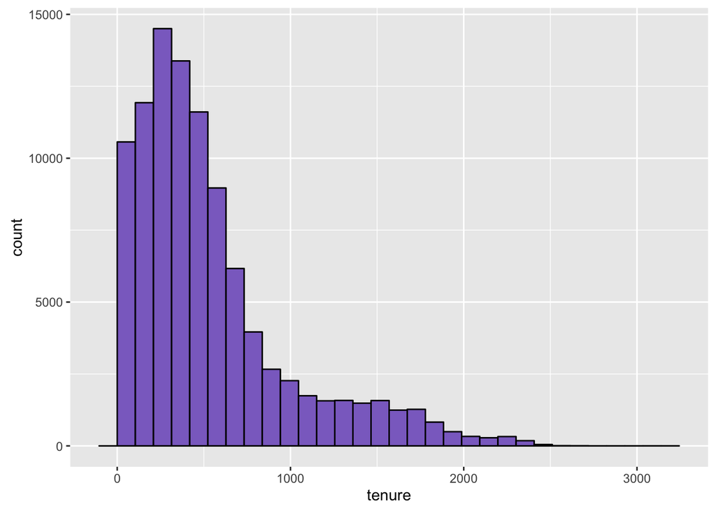

```r
qplot(x = tenure, data = pf, color = I("black"), fill = I("#8C70C9"))
```

#### How would you create a histogram of tenure by year?

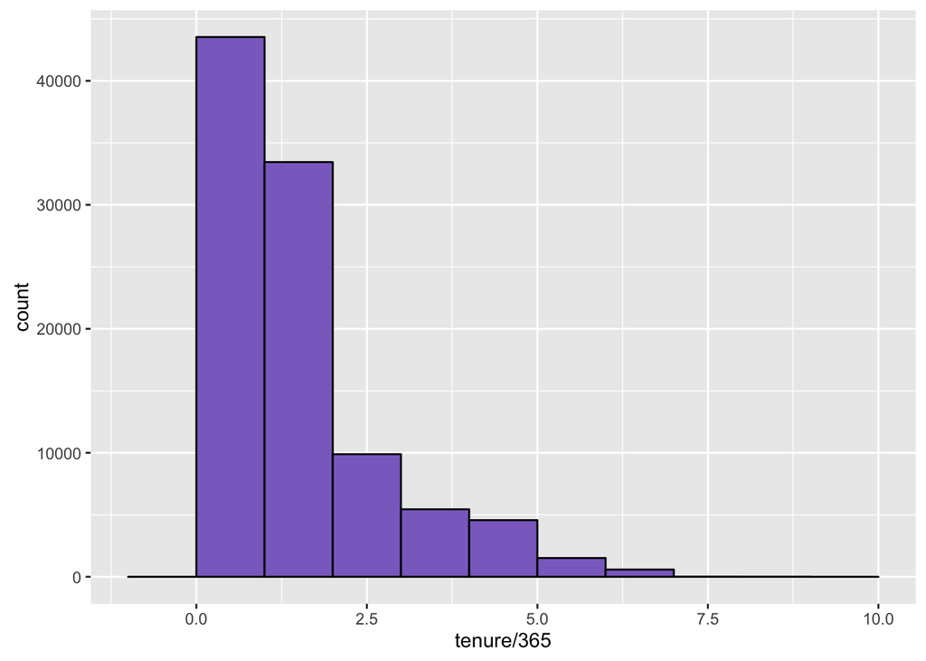

```r
qplot(x = tenure/365, data = pf, binwidth = 1, color = I("black"), fill = I("#8C70C9"))
```

### Labeling Plots

Notes: Just use the xlab/ylab parameters

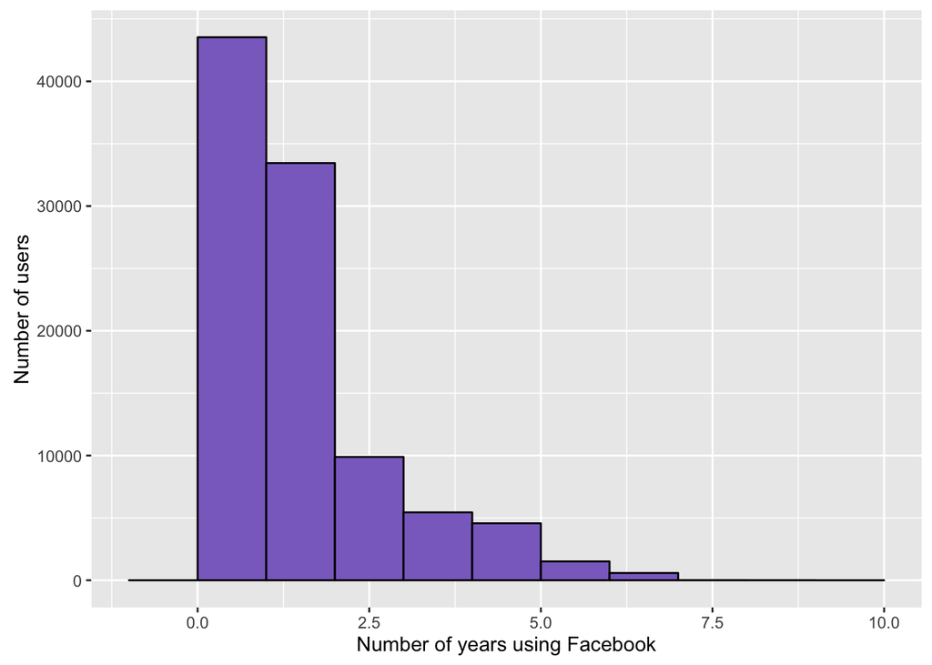

```r
qplot(x = tenure/365, data = pf, binwidth = 1,
            xlab = "Number of years using Facebook",
            ylab = "Number of users",
            color = I("black"), fill = I("#8C70C9"))
```

### User Ages

Notes:

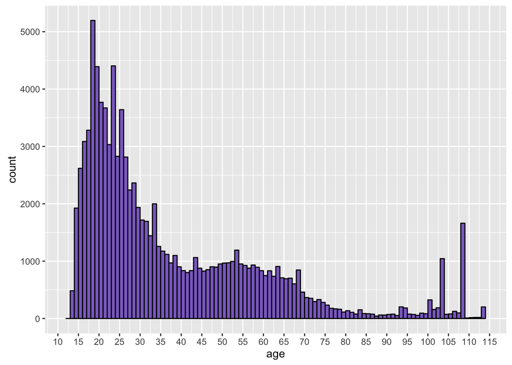

```r
qplot(x = age, data = pf, binwidth = 1, color = I("black"), fill = I("#8C70C9")) +
    scale_x_continuous(breaks = seq(0, 150, by = 5))
```

### The Spread of Memes

Notes: Using logarithms, data can be normalized to decrease the impact of over-dispersion. Log(0) is undefined, so add one to values that might be zero. Log10 basically transforms data into orders of magnitude instead of absolute values. ***

### Lada’s Money Bag Meme

Notes:

### Transforming Data

Notes:

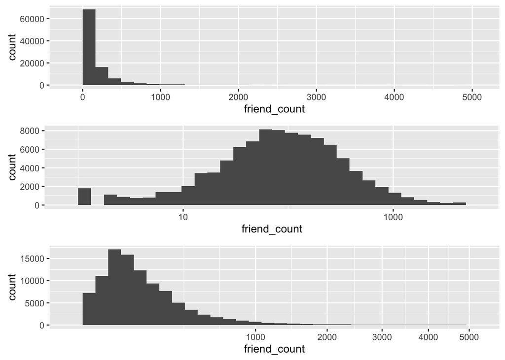

```r
#no_scale <- qplot(x = friend_count+1, data = pf, binwidth = 50, color = I("black"), fill = I("#8C70C9"))
#log10_scale <- qplot(x = log10(friend_count+1), data = pf, binwidth = 0.2, color = I("black"), fill = I("#8C70C9"))
#sqrt_scale <- qplot(x = sqrt(friend_count+1), data = pf, binwidth = 50, color = I("black"), fill = I("#8C70C9"))

# This is better because the friendly labeling of the x axis is more readable.
# log10 will label the axis with actual values instead of log units.
no_scale <- ggplot(aes(x = friend_count), data = pf) + geom_histogram()
log10_scale <- no_scale + scale_x_log10()
sqrt_scale <- no_scale + scale_x_sqrt()

grid.arrange(no_scale, log10_scale, sqrt_scale, ncol = 1)
```

### Add a Scaling Layer

Notes:

### Frequency Polygons

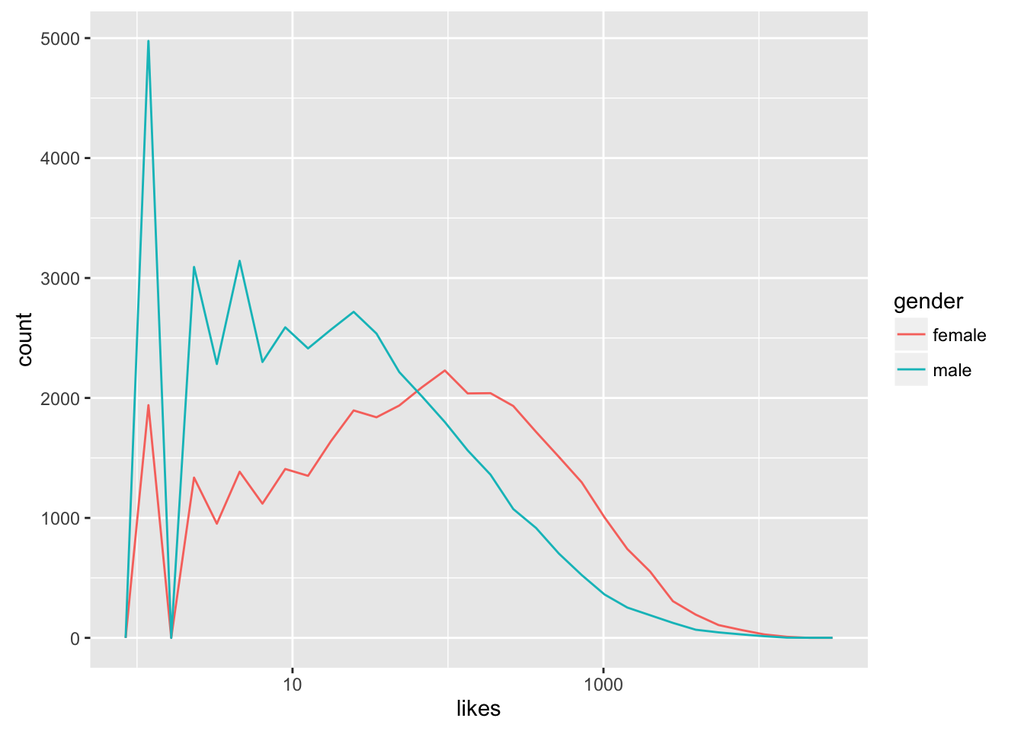

```r
#qplot(x = log10(likes),
#       data = subset(pf, !is.na(gender)),
#       xlab = "Likes",
#       ylab = "Number of Users",
#       binwidth = 500,
#       geom = "freqpoly") +
#   facet_wrap(~gender)
#   scale_x_log10()

qplot(x = likes,
        data = subset(pf, !is.na(gender)),
        geom = "freqpoly",
        color = gender) +
    scale_x_continuous() +
    scale_x_log10()
```

### Likes on the Web

Notes:

```r
by(pf$likes, pf$gender, sum)
```

```
## pf$gender: female
## [1] 10468106
## --------------------------------------------------------
## pf$gender: male
## [1] 4959923
```

### Box Plots

Notes:

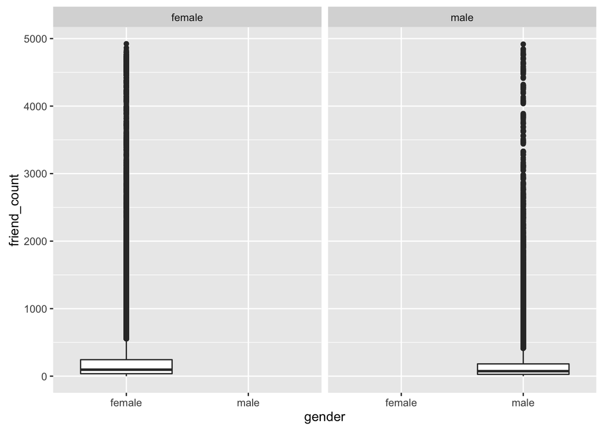

```r
qplot(x = gender,
        y = friend_count,
        data = subset(pf, !is.na(gender)),
        geom = "boxplot") +
    facet_wrap(~gender)
```

#### Adjust the code to focus on users who have friend counts between 0 and 1000.

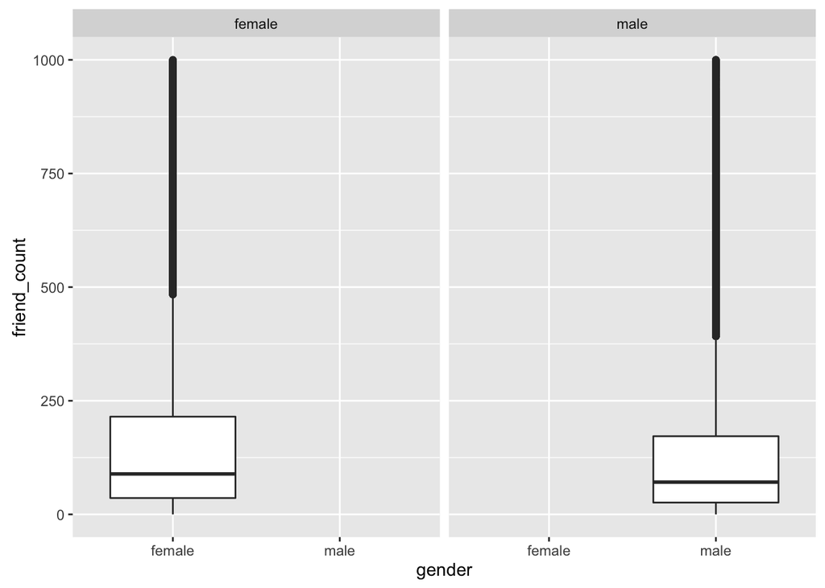

```r
qplot(x = gender,
        y = friend_count,
        data = subset(pf, !is.na(gender)),
        geom = "boxplot") +
    scale_y_continuous(limits = c(0, 1000)) +
    facet_wrap(~gender)
```

### Box Plots, Quartiles, and Friendships

Notes: coord_cartesian() is better for setting the y limits. scale_y_continuous() changes the actual values displayed.

```r
by(pf$friendships_initiated, pf$gender, summary)
```

```
## pf$gender: female
##    Min. 1st Qu.  Median    Mean 3rd Qu.    Max.
##     0.0    19.0    49.0   113.9   124.8  3654.0
## --------------------------------------------------------
## pf$gender: male
##    Min. 1st Qu.  Median    Mean 3rd Qu.    Max.
##     0.0    15.0    44.0   103.1   111.0  4144.0
```

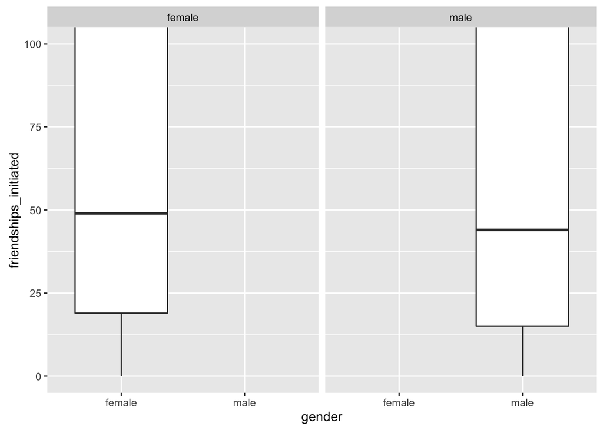

```r
qplot(x = gender,
        y = friendships_initiated,
        data = subset(pf, !is.na(gender)),
        geom = "boxplot") +
    coord_cartesian(ylim = c(0, 100)) +
    facet_wrap(~gender)
```

#### On average, who initiated more friendships in our sample: men or women?

Response:

### Getting Logical

Notes:

Response:

### Analyzing One Variable

Reflection:

Click **KnitHTML** to see all of your hard work and to have an html page of this lesson, your answers, and your notes!